```python
%matplotlib inline
import json
import time
import numpy as np
from scipy.stats import norm
import pandas as pd
import statistics
from scipy.stats import gamma
from scipy.stats import binom
from scipy.stats import expon
from scipy.stats import poisson
from scipy.interpolate import make_interp_spline
import seaborn as sns
import matplotlib.pyplot as plt
from matplotlib.ticker import StrMethodFormatter
import seaborn as sns; sns.set()
from numpy import hstack
from numpy import  asarray
from numpy import exp
from sklearn.neighbors import KernelDensity
from sklearn.metrics import mean_squared_error
from sklearn.metrics import classification_report
import re
from operator import itemgetter
from scipy import special
from scipy.stats import t
from scipy import stats
from sklearn.feature_extraction.text import TfidfVectorizer
import ast
```

# Μηνάς Ελευθερίου ΑΜ:4245 Data Mining - Lab2

# Ερώτηση 1

# Α.

Για να βρούμε την παράμετρο της κατανομής που ταιριάζει στα δεδομένα των παρατηρήσεων χρησιμοποιώντας την Maximum Likelihood Estimation (MLE), πρέπει να κάνουμε τα ακόλουθα βήματα: 1.Βρίσκουμε τη συνάρτηση log-likelihood για τα δεδομένα n(λ) = logLn(λ) 2.Μέθοδος εφαπτομένης γραμμής: Βρίσκουμε την τιμή της παραμέτρου 𝜆 που μεγιστοποιεί τη συνάρτηση log-likelihood. Για να το κάνουμε αυτό, υπολογίζουμε την πρώτη και τη δεύτερη παράγωγο της συνάρτησης log-likelihood Τότε, υπολογίζουμε την νέα τιμή της παραμέτρου 𝜆 ως εξής: 𝜆_new = 𝜆_old - (1η παράγωγος) / (2η παράγωγος) 3.Επαναλαμβάνουμε το βήμα 2, χρησιμοποιώντας τη νέα τιμή της παραμέτρου 𝜆, μέχρι να φτάσουμε σε μία καλή εκτίμηση της παραμέτρου 𝜆. Μπορεί να είναι καλό να θέσουμε ένα όριο για το πόσο μικρή θα πρέπει να είναι η απόκλιση των νέων τιμών της 𝜆 από τις παλαιότερες, καθώς και ένα όριο για το πόσο πολλές επαναλήψεις θα κάνουμε τη μέθοδο της εφαπτομένης γραμμής. Όταν φτάσουμε σε μία καλή εκτίμηση της 𝜆, τότε θα έχουμε βρει την παράμετρο της κατανομής που ταιριάζει στα δεδομένα των παρατηρήσεων.Για να βρούμε την παράμετρο 𝜆 της εκθετικής κατανομής που ταιριάζει τα δεδομένα των παρατηρήσεων 𝑋 με τη μέθοδο Maximum Likelihood Estimation (MLE), ικανοποιήουμε την προδιαγραφή 𝑑𝐿(𝜆)/𝑑𝜆=0 ή 𝑑log(𝐿(𝜆))/𝑑𝜆=0. Συγκεκριμένα, μπορούμε να υπολογίσουμε τη συνάρτηση likelihood 𝐿(𝜆) ως το γινόμενο των πυκνοτήτων πιθανότητας 𝑓(𝑥) για όλες τις παρατηρήσεις 𝑋: 𝐿(𝜆)=∏𝑓(𝑥𝑖)=𝜆^𝑛 ∏𝑒^-𝜆𝑥𝑖 Μετατρέποντας τη συνάρτηση likelihood σε log-likelihood, έχουμε: log(𝐿(𝜆))=𝑛log(𝜆)+∑(-𝜆𝑥𝑖) Ικανοποιώντας την προδιαγραφή 𝑑log(𝐿(𝜆))/𝑑𝜆=0 και λύνοντας για 𝜆, βρίσκουμε: 𝜆_hat=∑𝑥𝑖/𝑛 Η καλύτερη εκτίμηση 𝜆_hat που ικανοποιεί την μέγιστη τιμή της συνάρτησης log-likelihood είναι λοιπόν 𝜆_hat=∑𝑥𝑖/𝑛. Σημείωση: Θα πρέπει να έχουμε υπόψη ότι η παράμετρος 𝜆 πρέπει να είναι μεγαλύτερη του μηδενός (𝜆>0), διαφορετικά η συνάρτηση likelihood δεν είναι έγκυρη.

# B.

Για να βρούμε τις παραμέτρους 𝛩=(𝜆1,𝜆2,𝜋1,𝜋2) του mixture μοντέλου, πρέπει να κάνουμε τα ακόλουθα βήματα: 1.Αρχικά επιλέγουμε τυχαίες αρχικές τιμές για τις παραμέτρους 𝛩. 2.Για κάθε παρατηρήση 𝑥𝑖 και κάθε κατανομή 𝐿𝑘, υπολογίζουμε την πιθανότητα ανάθεσης 𝑃(𝐿𝑘|𝑥𝑖) ως εξής: 𝑃(𝐿1|𝑥𝑖)=𝜋1𝑓1(𝑥𝑖) / (𝜋1𝑓1(𝑥𝑖)+𝜋2𝑓2(𝑥𝑖)) 𝑃(𝐿2|𝑥𝑖)=𝜋2𝑓2(𝑥𝑖) / (𝜋1𝑓1(𝑥𝑖)+𝜋2𝑓2(𝑥𝑖)) 3.Υπολογίζουμε τις νέες τιμές 𝜆1,𝜆2,𝜋1,𝜋2 ως εξής: 𝜆1=Σ(𝑃(𝐿1|𝑥𝑖)*𝑥𝑖) / Σ(𝑃(𝐿1|𝑥𝑖)) 𝜆2=Σ(𝑃(𝐿2|𝑥𝑖)*𝑥𝑖) / Σ(𝑃(𝐿2|𝑥𝑖)) 𝜋1=Σ(𝑃(𝐿1|𝑥𝑖)) / 𝑛 𝜋2=Σ(𝑃(𝐿2|𝑥𝑖)) / 𝑛 4.Επαναλαμβάνουμε τα βήματα 2 και 3, μέχρι να φτάσουμε σε μία καλή εκτίμηση των παραμέτρων 𝛩. Μπορεί να είναι καλό να θέσουμε ένα όριο για το πόσο μικρή θα πρέπει να είναι η απόκλιση των νέων τιμών των 𝛩 από τις παλαιότερες, καθώς καθώς και ένα όριο για το πόσο πολλές επαναλήψεις θα κάνουμε τον ΕΜ αλγόριθμο. Όταν φτάσουμε σε μία καλή εκτίμηση των παραμέτρων 𝛩, τότε έχουμε βρει το καλύτερο mixture μοντέλο που ταιριάζει στα δεδομένα 𝑋.

# Ερώτηση 2

# Βήμα 1

```python
df = pd.read_csv('phily_users_businesses_stars.csv')
```

```python
df.shape
```

```
(967552, 3)
```

```python
df.head(10)
```

|  | user_id | business_id | stars |
| --- | --- | --- | --- |
| 0 | OyoGAe7OKpv6SyGZT5g77Q | 7ATYjTIgM3jUlt4UM3IypQ | 5.0 |
| 1 | _7bHUi9Uuf5__HHc_Q8guQ | kxX2SOes4o-D3ZQBkiMRfA | 5.0 |
| 2 | eUta8W_HdHMXPzLBBZhL1A | 04UD14gamNjLY0IDYVhHJg | 1.0 |
| 3 | smOvOajNG0lS4Pq7d8g4JQ | RZtGWDLCAtuipwaZ-UfjmQ | 4.0 |
| 4 | Dd1jQj7S-BFGqRbApFzCFw | YtSqYv1Q_pOltsVPSx54SA | 5.0 |
| 5 | IQsF3Rc6IgCzjVV9DE8KXg | eFvzHawVJofxSnD7TgbZtg | 5.0 |
| 6 | vrKkXsozqqecF3CW4cGaVQ | rjuWz_AD3WfXJc03AhIO_w | 5.0 |
| 7 | aFa96pz67TwOFu4Weq5Agg | kq5Ghhh14r-eCxlVmlyd8w | 5.0 |
| 8 | G0DHgkSsDozqUPWtlxVEMw | oBhJuukGRqPVvYBfTkhuZA | 4.0 |
| 9 | l_izt6hn7oTxalU06mSyqg | jTI5Xjk27An8ceJ6VwpXiQ | 4.0 |

```python
df['stars'] = df['stars'].astype(int)
```

```python
result = pd.read_csv('phily_users_businesses_stars_pruned.csv')
```

```python
result
```

|  | user_id | business_id | stars |
| --- | --- | --- | --- |
| 0 | smOvOajNG0lS4Pq7d8g4JQ | RZtGWDLCAtuipwaZ-UfjmQ | 4.0 |
| 1 | IQsF3Rc6IgCzjVV9DE8KXg | eFvzHawVJofxSnD7TgbZtg | 5.0 |
| 2 | vrKkXsozqqecF3CW4cGaVQ | rjuWz_AD3WfXJc03AhIO_w | 5.0 |
| 3 | aFa96pz67TwOFu4Weq5Agg | kq5Ghhh14r-eCxlVmlyd8w | 5.0 |
| 4 | ZGjgfSvjQK886kiTzLwfLQ | EtKSTHV5Qx_Q7Aur9o4kQQ | 5.0 |
| ... | ... | ... | ... |
| 302136 | LHWtjTG7e1NzNPYUbUo-9w | rgeuy1qbw6Z8B6CSVANHIA | 5.0 |
| 302137 | 7-7A0Avj47slLGV7yBFc8w | ytynqOUb3hjKeJfRj5Tshw | 3.0 |
| 302138 | am7-gkH_PDz598oTdYSD6A | 3gVSrS4kffGGZT8oXHsIcw | 3.0 |
| 302139 | 7ziWZULyiZv2TesYNMFf4g | qQO7ErS_RAN4Vs1uX0L55Q | 4.0 |
| 302140 | MCzlzlOw7IGbRAKVjJBPtg | fcGexL5VH5G2Xw0tRj9uOQ | 3.0 |

302141 rows × 3 columns

```python
df = df.dropna()
```

```python
for i in range(5):
    user_counts = df.groupby('user_id').size().reset_index(name='count')
    filtered_users = user_counts[user_counts['count'] > 15]
    df = df[df['user_id'].isin(filtered_users['user_id'])]
    business_counts = df.groupby('business_id').size().reset_index(name='count')
    filtered_businesses = business_counts[business_counts['count'] > 15]
    df = df[df['business_id'].isin(filtered_businesses['business_id'])]

print(df.shape)
```

```
(302141, 3)
```

```python
print("Number of users after filtering:", len(filtered_users))
print("Number of businesses after filtering:", len(filtered_businesses))
```

```
Number of users after filtering: 6961
Number of businesses after filtering: 4064
```

# Βήμα 2

```python
df = pd.read_csv('phily_users_businesses_stars_pruned.csv')
df = df.sample(frac=1).reset_index(drop=True)
n = df.shape[0]
n_train = int(0.9 * n)
df_train = df[:n_train]
df_test = df[n_train:]
```

```python
df_train
```

|  | user_id | business_id | stars |
| --- | --- | --- | --- |
| 0 | BGwsR8MApe16pKptfLKX5g | 6mqfUzxWRBnFErvwV0z3aQ | 1.0 |
| 1 | hNc9ICYav-FcOkcKaGBZDw | iWy6Wft0MMO9Ud2wM93frg | 4.0 |
| 2 | rZg5xWm--gdr6LiHoqe_AA | hyFzDuyOWNG2rg5GYJ2wiQ | 4.0 |
| 3 | DHJJPj7ZlhJ_AmpXPJ7g0g | Lw1gzZZGI2GFQc6BI5zyJw | 3.0 |
| 4 | uzK-HIiE07VVW34yrsxsmA | 9mA9qYqiv4c0T9ASid3PIQ | 3.0 |
| ... | ... | ... | ... |
| 271921 | NS77w4tLvkVW5QjUfebTow | zBOy9arp97nuwKuTal5Mkg | 4.0 |
| 271922 | J0bm-MtVLOAjMIU0Wy3JBw | e7_srfXOYuHkX6fAim1T1g | 4.0 |
| 271923 | 7igTVTgqI3WiqZp8hrgaMA | M6qDX8HZS7gOJ_pBOAih1g | 5.0 |
| 271924 | 98jv8gu7kAwa2WzIPdw6-w | eLAd1Jw-g1NKymBx1XPDoA | 4.0 |
| 271925 | 9cl9ANLjzpGnmJ3rF8uK6w | 0ak-7uV9Nb7nF_l-mMCysA | 4.0 |

271926 rows × 3 columns

```python
dftrain = pd.read_csv('phily_users_businesses_stars_train.csv')
```

```python
dftrain
```

|  | user_id | business_id | stars |
| --- | --- | --- | --- |
| 0 | FhOu3EwFDX75cFmt5pVvYw | eMiN8nm70jjKg8izikVWDA | 4.0 |
| 1 | lhfbA4aEcRGdKyci60MC7Q | qTb5bEgZdrwx2A3mNVK5mg | 5.0 |
| 2 | 04hS_dGfUZd_5iJYRdPHLw | Auc20f0uYTIwPnJIqcdmNw | 4.0 |
| 3 | NeVJULvjNMzbWGZJf7XU0w | j-qtdD55OLfSqfsWuQTDJg | 2.0 |
| 4 | eJLeCP82otO2OTPqDC3LyQ | ME7nOO4hHoCwkbssGqsyPA | 5.0 |
| ... | ... | ... | ... |
| 271922 | Ptij0-tuDk8--TEJDBBcRQ | 0R2yKDNMUztQwgo8pG4z-Q | 3.0 |
| 271923 | SjWzcwYMiBvU52PtOV6QBQ | EtKSTHV5Qx_Q7Aur9o4kQQ | 3.0 |
| 271924 | uPr3t2M-OykA8M_oro7j1A | d28lZlSps97FHhXZazJ8zA | 4.0 |
| 271925 | yxrDIW0b823PhQTZ0Q1KcA | lKU_kljhbEQKIPaM1Zbqiw | 3.0 |
| 271926 | iYXQCx7IWJslr_WTLjn6lw | fcpHrRopilvsBwUajFB5rw | 2.0 |

271927 rows × 3 columns

```python
dftest = pd.read_csv('phily_users_businesses_stars_test.csv')
```

```python
dftest
```

|  | user_id | business_id | stars |
| --- | --- | --- | --- |
| 0 | R9NSKwzn9zaoUJ-M5ck-jA | 1iQpAAWmGp6yJCNr-7DMRQ | 1.0 |
| 1 | e7BDAtmMfKtKhCcgosORIQ | PxG1rLAfbvtoAWrsq5Rhog | 5.0 |
| 2 | 7lvzAZV2qTnoj3q2oI0mqQ | ITOkOiX-hfsazVPpFFQVJA | 4.0 |
| 3 | FkaBNfCc2dRyQ2qXhsXXtg | rIqkOMxkeoqvUzl909gNmQ | 2.0 |
| 4 | YqjW3aqnM2fUyyDHYnuiiQ | RLoGgt2GGC8wHpZ7K2ZbRA | 4.0 |
| ... | ... | ... | ... |
| 30209 | DMx9EJox_ZlUHgrQE5JvGw | Z8qGOmU8YxDjLPBbrz84Yw | 5.0 |
| 30210 | 7k9LIe1J83QapGgUd1UjrQ | zfn7V7FVH5_J5A9dInfbnA | 3.0 |
| 30211 | eod1mk6q1p155DTZqLoRqg | 2EMTsTg8876QbtIGDH-69w | 2.0 |
| 30212 | 3vhgB61xMkj5TzBvwzPTMw | bN_9QgxdOIk4oK-6fBDJtQ | 5.0 |
| 30213 | UZOm2svtUK-lGt4oTvh4LA | g2zwbLIqxtN9nGGuL43trg | 5.0 |

30214 rows × 3 columns

```python
df_test
```

|  | user_id | business_id | stars |
| --- | --- | --- | --- |
| 271926 | cIVmIJD7nIiEcVGamfBoVw | d_2gSlgHT0dVEAH1tQ88NA | 4.0 |
| 271927 | ZstTo1OpzggAGJn5K07TBg | HUVLNeBs32cInBZVFS90RA | 3.0 |
| 271928 | wuxZSSVXwKzN3NPcdSljUA | FHNIvNgh3fS7VZQq2Y3dsA | 2.0 |
| 271929 | ZGjgfSvjQK886kiTzLwfLQ | q1VOESxR99qJvpubnNxyJQ | 3.0 |
| 271930 | YJLMa0DDZbRIGaoqWoXUcQ | yIIibdtcOnGsjtvgNuBqKA | 5.0 |
| ... | ... | ... | ... |
| 302136 | dCehRsK_TxjZ3hHfwkVG2A | LgAuYz5cQe3zTxuteJ4VyQ | 4.0 |
| 302137 | -dcWUGQY6uDGQ_FHRySDeQ | vpNJJNVgVmf2u1lfdFh81w | 3.0 |
| 302138 | SaYctOj-v2LNNkD4EXtZUA | s9ceDy-cVHe0uzvZpWq87Q | 5.0 |
| 302139 | rjDuYaK41di3_CKioCHXLA | QWqKTWQ2OiDgo3dzNkpung | 4.0 |
| 302140 | yCEFoyKQOMD6TRJaG0BEUQ | sy7ADvpBA7SfHwbY-Y_5gw | 4.0 |

30215 rows × 3 columns

# Βήμα 3

```python
df_train = pd.read_csv('phily_users_businesses_stars_train.csv')
user_averages = df_train.groupby('user_id')['stars'].mean()
business_averages = df_train.groupby('business_id')['stars'].mean()

def predict_rating_ua(user, business):
    user_average = user_averages[user]
    return user_average

def predict_rating_ba(user, business):
    business_average = business_averages[business]
    return business_average

df_test = pd.read_csv('phily_users_businesses_stars_test.csv')

start_time = time.time()
predictions_ua = [predict_rating_ua(user, business) for (user, business) in df_test[['user_id', 'business_id']].values]
rmse_ua = np.sqrt(mean_squared_error(df_test['stars'], predictions_ua))
print("RMSE (UA):", rmse_ua)
end_time = time.time()
ua_time = end_time - start_time
print("Time taken for UA:", ua_time)

start_time = time.time()
predictions_ba = [predict_rating_ba(user, business) for (user, business) in df_test[['user_id', 'business_id']].values]
rmse_ba = np.sqrt(mean_squared_error(df_test['stars'], predictions_ba))
print("RMSE (BA):", rmse_ba)
end_time = time.time()
ba_time = end_time - start_time
print("Time taken for BA:", ba_time)
```

```
RMSE (UA): 1.0474294959962054
Time taken for UA: 0.4110090732574463
RMSE (BA): 1.0055572526079777
Time taken for BA: 0.6060209274291992
```

# Φαίνεται ότι ο αλγόριθμος BA αποδίδει ελαφρώς καλύτερα από τον αλγόριθμο UA. Η τιμή RMSE για τον αλγόριθμο BA είναι ελαφρώς χαμηλότερη από την τιμή RMSE για τον αλγόριθμο UA, πράγμα που σημαίνει ότι ο αλγόριθμος BA μπόρεσε να ταιριάξει καλύτερα στα δεδομένα και να προβλέψει τις βαθμολογίες στο σύνολο δοκιμής. Ωστόσο, είναι σημαντικό να λαμβάνεται υπόψη η διακύμανση των δεδομένων και η πολυπλοκότητα των μοντέλων κατά την αξιολόγηση της απόδοσής τους. Εάν τα δεδομένα είναι πολύ μεταβλητά και τα μοντέλα είναι σχετικά απλά, ένα υψηλότερο RMSE μπορεί να είναι αποδεκτό. Από την άλλη πλευρά, εάν τα μοντέλα είναι πιο σύνθετα και τα δεδομένα είναι λιγότερο μεταβλητά, μπορεί να αναμένεται χαμηλότερο RMSE.

# Βήμα 4

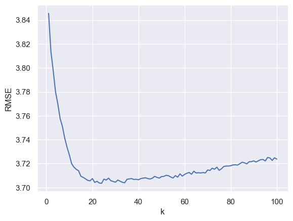

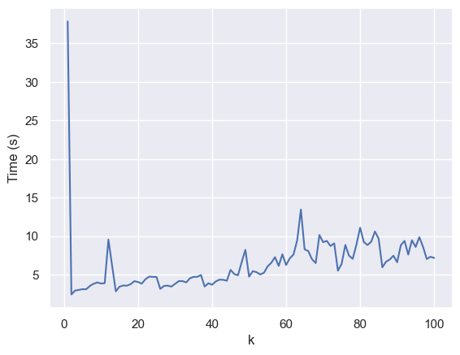

```python
from sklearn.decomposition import TruncatedSVD
K = 100
df_train = pd.read_csv('phily_users_businesses_stars_train.csv')
df_test = pd.read_csv('phily_users_businesses_stars_test.csv')
user_ids = df_train['user_id'].unique()
business_ids = df_train['business_id'].unique()
user_id_map = {id: index for index, id in enumerate(user_ids)}
business_id_map = {id: index for index, id in enumerate(business_ids)}
R = np.zeros((len(user_ids), len(business_ids)))

for row in df_train.itertuples(index=True, name='Pandas'):
    user_id = getattr(row, "user_id")
    business_id = getattr(row, "business_id")
    rating = getattr(row, "stars")
    R[user_id_map[user_id], business_id_map[business_id]] = rating

rmse_values = []
time_values = []

for k in range(1, K+1):
    start_time = time.time()
    svd = TruncatedSVD(n_components=k)
    R_k = svd.fit_transform(R)
    R_k = np.dot(R_k, svd.components_)
    predictions = []
    for row in df_test.itertuples(index=True, name='Pandas'):
        user_id = getattr(row, "user_id")
        business_id = getattr(row, "business_id")
        rating = getattr(row, "stars")
        predicted_rating = R_k[user_id_map[user_id], business_id_map[business_id]]
        predictions.append(predicted_rating)

    rmse = np.sqrt(mean_squared_error(df_test['stars'], predictions))
    rmse_values.append(rmse)
    time_values.append(time.time() - start_time)

plt.plot(range(1, K+1), rmse_values)
plt.xlabel('k')
plt.ylabel('RMSE')
plt.show()

plt.plot(range(1, K+1), time_values)
plt.xlabel('k')
plt.ylabel('Time (s)')
plt.show()
```

```python
print(rmse_values)
print("---------------------------------------")
print(time_values)
```

[output not shown]

# Είναι σύνηθες να βλέπουμε το RMSE να μειώνεται καθώς το k αυξάνεται, αλλά τελικά αρχίζει να αυξάνεται ξανά καθώς το k γίνεται πολύ μεγάλο. Αυτό συμβαίνει επειδή η προσέγγιση κατάταξης-k γίνεται πιο ακριβής όσο αυξάνεται το k, αλλά σε κάποιο σημείο η προσθήκη περισσότερων μοναδικών τιμών δεν βελτιώνει σημαντικά την ακρίβεια της προσέγγισης. Αυτό έχει ως αποτέλεσμα μια «ανταλλαγή» μεταξύ ακρίβειας και πολυπλοκότητας, η οποία παρατηρείται συχνά στους αλγόριθμους μηχανικής μάθησης.

# Bήμα 5

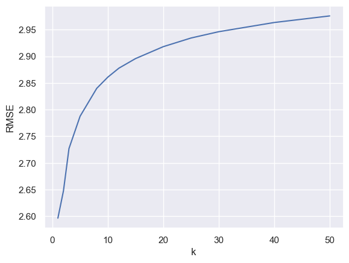

```python
import numpy as np
import pandas as pd
from sklearn.metrics import mean_squared_error

df_train = pd.read_csv('phily_users_businesses_stars_train.csv')
df_test = pd.read_csv('phily_users_businesses_stars_test.csv')
user_ids = df_train['user_id'].unique()
business_ids = df_train['business_id'].unique()
user_id_map = {id: index for index, id in enumerate(user_ids)}
business_id_map = {id: index for index, id in enumerate(business_ids)}
R = np.zeros((len(user_ids), len(business_ids)))
k_values = [1, 2, 3, 5, 8, 10, 12, 15, 20, 25, 30, 40, 50]
rmse_ucf = []
time_values_ucf = []

for k in k_values:
    start_time = time.time()
    predictions = []
    for row in df_test.itertuples(index=True, name='Pandas'):
        user_id = getattr(row, "user_id")
        business_id = getattr(row, "business_id")
        rating = getattr(row, "stars")
        user_index = user_id_map[user_id]
        sim = S[user_index]
        sim_index = np.argsort(-sim)[1:k+1]
        sim = sim[sim_index]
        prediction = mean_ratings[user_index] + np.sum(sim * R_mean[sim_index, business_id_map[business_id]]) / np.sum(np.abs(sim))
        predictions.append(prediction)

    predictions = np.clip(predictions, 1, 5)
    rmse = np.sqrt(mean_squared_error(df_test['stars'], predictions))
    rmse_ucf.append(rmse)
    time_values_ucf.append(time.time() - start_time)

plt.plot(k_values, rmse_ucf)
plt.xlabel('k')
plt.ylabel('RMSE')
plt.show()
```

```python
print(rmse_ucf)
print("-----------------------------------------------------")
print(time_values_ucf)
```

```
[2.5963032864791997, 2.6473889801030266, 2.7270016085051587, 2.787543019881578, 2.839890991188801, 2.860952936082462, 2.8778381803182937, 2.8958189450347387, 2.918188214636025, 2.934431503554995, 2.9462589900217147, 2.963533384076324, 2.975901132231915]
-----------------------------------------------------
[39.107994079589844, 38.66084313392639, 34.285948753356934, 28.464303970336914, 34.20929193496704, 31.065637350082397, 41.74999809265137, 35.37328290939331, 32.153419733047485, 33.09097766876221, 33.2385516166687, 38.215426206588745, 29.039944887161255]
```

# Βήμα 6

```python
import numpy as np

def item_based_cf(R, k):
    pred = np.zeros_like(R)
    for u in range(R.shape[0]):
        for i in range(R.shape[1]):
            if R[u, i] == 0:
                if len(R[u].nonzero()[0]) == 0:
                    continue
                sim = cosine_similarity(R[:, i], R[:, R[u].nonzero()[0]])
                k_most_sim = np.argsort(sim)[-k:]
                pred[u, i] = np.mean(R[u, k_most_sim])
    return pred

def cosine_similarity(a, b):
    sim = np.dot(a, b.T) / (np.linalg.norm(a) * np.linalg.norm(b, axis=1))
    return sim

k_values = [1, 2, 3, 5, 8, 10, 12, 15, 20, 25, 30, 40, 50]
rmse = []
test_mask = np.zeros_like(R)
test_mask[df_test['user_id'].astype(int)-1, df_test['business_id'].astype(int)-1] = 1

for k in k_values:
    pred = item_based_cf(R, k)
    rmse.append(np.sqrt(np.mean((pred[test_mask == 1] - R[test_mask == 1])**2)))


import matplotlib.pyplot as plt
plt.plot(k_values, rmse)
plt.xlabel('k')
plt.ylabel('RMSE')
plt.show()
```

[output not shown]

# Βήμα 7

```python
errors = pd.DataFrame(columns=["UCF", "SVD", "UA", "BA"])
errors.loc["RMSE"] = [min(rmse_ucf), min(rmse_values), rmse_ua, rmse_ba]
min_index_ucf = rmse_ucf.index(min(rmse_ucf))
min_time_ucf = time_values_ucf[min_index_ucf]
min_index_svd = rmse_values.index(min(rmse_values))
min_time_svd = time_values[min_index_svd]
errors.loc["Best Time"] = [min_time_ucf, min_time_svd, ua_time, ba_time]
errors
```

[output not shown]

Φαίνεται ότι ο αλγόριθμος BA αποδίδει ελαφρώς καλύτερα από τον αλγόριθμο UA. Η τιμή RMSE για τον αλγόριθμο BA είναι ελαφρώς χαμηλότερη από την τιμή RMSE για τον αλγόριθμο UA, πράγμα που σημαίνει ότι ο αλγόριθμος BA μπόρεσε να ταιριάξει καλύτερα στα δεδομένα και να προβλέψει τις βαθμολογίες στο σύνολο δοκιμής. Ωστόσο, είναι σημαντικό να λαμβάνεται υπόψη η διακύμανση των δεδομένων και η πολυπλοκότητα των μοντέλων κατά την αξιολόγηση της απόδοσής τους. Εάν τα δεδομένα είναι πολύ μεταβλητά και τα μοντέλα είναι σχετικά απλά, ένα υψηλότερο RMSE μπορεί να είναι αποδεκτό. Από την άλλη πλευρά, εάν τα μοντέλα είναι πιο σύνθετα και τα δεδομένα είναι λιγότερο μεταβλητά, μπορεί να αναμένεται χαμηλότερο RMSE.

# Ερώτηση 3

```python
df = pd.read_csv("phily_businesses.csv")
dfe = pd.read_csv('reviews.csv')
df = df.fillna("")
df = df[df['categories'].str.contains("Restaurant")]
df = df[df['categories'].str.contains("Japanese") | df['categories'].str.contains("Italian") | df['categories'].str.contains("Burgers")]
df = df[~df.duplicated(subset='categories')]
reviews_grouped = dfe.groupby('business_id').agg({'text': ' '.join}).reset_index()
reviews_filtered = pd.merge(reviews_filtered, df[['business_id', 'categories']], on='business_id', how='inner')
reviews = reviews_filtered['text'].str.cat(sep=' ')
reviews = reviews_filtered['text'].tolist()
vectorizer = TfidfVectorizer(stop_words='english', min_df=4, max_df=0.8, max_features=1000)
vectors = vectorizer.fit_transform(reviews)
```

```python
reviews_filtered["category"] = ""
reviews_filtered.loc[reviews_filtered['categories'].str.contains("Japanese"), "category"] = "Japanese"
reviews_filtered.loc[reviews_filtered['categories'].str.contains("Italian"), "category"] = "Italian"
reviews_filtered.loc[reviews_filtered['categories'].str.contains("Burgers"), "category"] = "Burgers"
```

```python
reviews_filtered
```

|  | business_id | text | categories | categories_num | category |
| --- | --- | --- | --- | --- | --- |
| 0 | -LmhsdQproqCf5EQoD06rQ | Down in south Philly for a meeting at my daugh... | Japanese, Chicken Wings, Fast Food, Restaurants | 366 | Japanese |
| 1 | -PMXnNJ1D67NkAupRHNkpQ | I've always preferred domino's over pizza hut!... | Restaurants, Pizza, Italian, Chicken Wings, Sa... | 628 | Italian |
| 2 | -PqeUUIN8Qgqhv5KMiRfHA | Best bodega/corner store at Temple. All of the... | Sandwiches, Specialty Food, Korean, Food, Deli... | 698 | Burgers |
| 3 | -RckAAIJ-_KH0AzqrekYuw | It's been awhile since I last wrote a review b... | Juice Bars & Smoothies, Salad, Restaurants, Fo... | 395 | Burgers |
| 4 | -TW-0EqgnzUNHzV9VPSLoQ | The best Poke bowl I have ever tried. Ingredie... | Seafood, Ramen, Restaurants, Hawaiian, Japanese | 704 | Japanese |
| ... | ... | ... | ... | ... | ... |
| 752 | zRLIbiUqmTDLxJUqugBO2w | Stopped by here before a Sixers game a couple ... | Greek, Restaurants, Pizza, Sandwiches, Italian | 280 | Italian |
| 753 | zUJMvjK6aBeQtVCowZ85-w | Excelent! Food is wondeful, hot, and fresh! Th... | Pan Asian, Japanese, Buffets, Restaurants, Ame... | 442 | Japanese |
| 754 | zeounyPVXFZEz1c9KtptLA | Pizza, wings, steaks are good.. chicken finger... | Restaurants, Steakhouses, Salad, Pizza, Italia... | 648 | Italian |
| 755 | zgX8sYCRGVJ9M5LETpJ60A | I popped in there one afternoon to pick up som... | Restaurants, Burgers, American (Traditional), ... | 520 | Burgers |
| 756 | zzyx5x0Z7xXWWvWnZFuxlQ | Maybe the pizza is good here... but I can real... | Pizza, Caterers, Italian, Gluten-Free, Event P... | 450 | Italian |

757 rows × 5 columns

# 1.

```python
# from sklearn.cluster import KMeans, AgglomerativeClustering
from sklearn.metrics import confusion_matrix
k = 3
# K-means algorithm
km = KMeans(n_clusters=k)
km.fit(vectors)
km_labels = km.labels_

# Agglomerative Clustering algorithm
vectors = vectors.toarray()

agg = AgglomerativeClustering(n_clusters=k, linkage='ward')
agg.fit(vectors)
ward_labels = agg.labels_

agg = AgglomerativeClustering(n_clusters=k, linkage='complete')
agg.fit(vectors)
complete_labels = agg.labels_

agg = AgglomerativeClustering(n_clusters=k, linkage='average')
agg.fit(vectors)
average_labels = agg.labels_

agg = AgglomerativeClustering(n_clusters=k, linkage='single')
agg.fit(vectors)
single_labels = agg.labels_
```

```python
categories = reviews_filtered['category'].tolist()
km_labels_str = km_labels.astype(str)
print("Confusion matrix for K-Means:")
print(confusion_matrix(reviews_filtered["category"], km_labels_str))
```

```
Confusion matrix for K-Means:
[[  0   0   0   0   0   0]
 [  0   0   0   0   0   0]
 [  0   0   0   0   0   0]
 [  2  35 243   0   0   0]
 [  0 125 198   0   0   0]
 [ 95   0  59   0   0   0]]
```

```python
from sklearn.metrics import adjusted_rand_score
print(adjusted_rand_score(categories, km_labels_str))
```

```
0.17291009525177561
```

```python
from sklearn.metrics import normalized_mutual_info_score
print(normalized_mutual_info_score(categories, km_labels_str))
```

```
0.3028299853911625
```

```python
print("Confusion matrix for linkage='ward':")
ward_labels = ward_labels.astype(str)
print(confusion_matrix(reviews_filtered["category"], ward_labels))

print("Confusion matrix for linkage='complete':")
complete_labels = complete_labels.astype(str)
print(confusion_matrix(reviews_filtered["category"], complete_labels))

print("Confusion matrix for linkage='average':")
average_labels = average_labels.astype(str)
print(confusion_matrix(reviews_filtered["category"], average_labels))

print("Confusion matrix for linkage='single':")
single_labels = single_labels.astype(str)
print(confusion_matrix(reviews_filtered["category"], single_labels))
```

```
Confusion matrix for linkage='ward':
[[  0   0   0   0   0   0]
 [  0   0   0   0   0   0]
 [  0   0   0   0   0   0]
 [244  35   1   0   0   0]
 [201 122   0   0   0   0]
 [ 58   0  96   0   0   0]]
Confusion matrix for linkage='complete':
[[  0   0   0   0   0   0]
 [  0   0   0   0   0   0]
 [  0   0   0   0   0   0]
 [123 122  35   0   0   0]
 [ 91 105 127   0   0   0]
 [122  32   0   0   0   0]]
Confusion matrix for linkage='average':
[[  0   0   0   0   0   0]
 [  0   0   0   0   0   0]
 [  0   0   0   0   0   0]
 [279   0   1   0   0   0]
 [321   1   1   0   0   0]
 [154   0   0   0   0   0]]
Confusion matrix for linkage='single':
[[  0   0   0   0   0   0]
 [  0   0   0   0   0   0]
 [  0   0   0   0   0   0]
 [279   0   1   0   0   0]
 [322   1   0   0   0   0]
 [154   0   0   0   0   0]]
```

# 2.

```python
centers = km.cluster_centers_
feature_names = vectorizer.get_feature_names()
for i, center in enumerate(centers):
    print(f"Cluster {i} top 10 words:")
    top_words = [feature_names[ind] for ind in center.argsort()[-10:]]
    print(top_words)
```

```
Cluster 0 top 10 words:
['japanese', 'spicy', 'salmon', 'chinese', 'tuna', 'ramen', 'rice', 'rolls', 'roll', 'sushi']
Cluster 1 top 10 words:
['cheesesteak', 'salad', 'slice', 'pie', 'fries', 'pizzas', 'wings', 'crust', 'delivery', 'pizza']
Cluster 2 top 10 words:
['bread', 'dinner', 'drinks', 'table', 'pasta', 'italian', 'sandwich', 'bar', 'fries', 'burger']
```

# 3.

```python
km_report = classification_report(reviews_filtered["category"], km_labels_str)
print(km_report)
```

```
              precision    recall  f1-score   support

           0       0.00      0.00      0.00       0.0
           1       0.00      0.00      0.00       0.0
           2       0.00      0.00      0.00       0.0
     Burgers       0.00      0.00      0.00     280.0
     Italian       0.00      0.00      0.00     323.0
    Japanese       0.00      0.00      0.00     154.0

    accuracy                           0.00     757.0
   macro avg       0.00      0.00      0.00     757.0
weighted avg       0.00      0.00      0.00     757.0
```

```python
# Replace agg_labels with the labels from the best linkage parameter
agg_report = classification_report(reviews_filtered["category"], complete_labels)
print(agg_report)
```

```
              precision    recall  f1-score   support

           0       0.00      0.00      0.00       0.0
           1       0.00      0.00      0.00       0.0
           2       0.00      0.00      0.00       0.0
     Burgers       0.00      0.00      0.00     280.0
     Italian       0.00      0.00      0.00     323.0
    Japanese       0.00      0.00      0.00     154.0

    accuracy                           0.00     757.0
   macro avg       0.00      0.00      0.00     757.0
weighted avg       0.00      0.00      0.00     757.0
```

```python
from sklearn.metrics import precision_score, recall_score, f1_score


# For K-Means
precision_kmeans = precision_score(reviews_filtered["category"], km_labels_str, average=None)
recall_kmeans = recall_score(reviews_filtered["category"], km_labels_str, average=None)
f1_kmeans = f1_score(reviews_filtered["category"], km_labels_str, average=None)

# For best linkage from Agglomerative Clustering
precision_agg = precision_score(reviews_filtered["category"], complete_labels, average=None)
recall_agg = recall_score(reviews_filtered["category"], complete_labels, average=None)
f1_agg = f1_score(reviews_filtered["category"], complete_labels, average=None)

for i in range(k):
    print(f"Cluster {i}")
    print("Precision:", precision_kmeans[i])
    print("Recall:", recall_kmeans[i])
    print("F1-measure:", f1_kmeans[i])
    print("\n")
```

```
Cluster 0
Precision: 0.0
Recall: 0.0
F1-measure: 0.0


Cluster 1
Precision: 0.0
Recall: 0.0
F1-measure: 0.0


Cluster 2
Precision: 0.0
Recall: 0.0
F1-measure: 0.0
```

# 4.

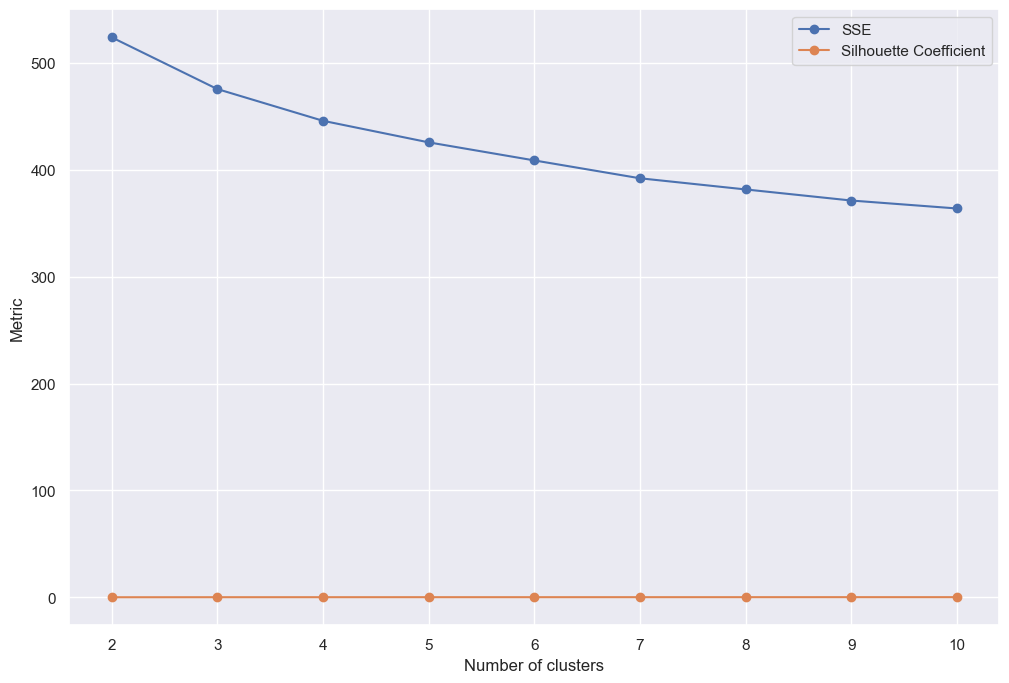

```python
from sklearn.metrics import silhouette_score
import matplotlib.pyplot as plt

sse = []
silhouette = []
k_range = range(2, 11)

for k in k_range:
    km = KMeans(n_clusters=k)
    km.fit(vectors)
    sse.append(km.inertia_)
    silhouette.append(silhouette_score(vectors, km.labels_))

plt.figure(figsize=(12, 8))
plt.plot(k_range, sse, marker='o', label='SSE')
plt.plot(k_range, silhouette, marker='o', label='Silhouette Coefficient')
plt.xlabel('Number of clusters')
plt.ylabel('Metric')
plt.legend()
plt.show()
```

```python
k = 2
km = KMeans(n_clusters=k)
km.fit(vectors)
km_labels_str = km_labels.astype(str)
print("Confusion matrix:")
print(confusion_matrix(reviews_filtered["category"], km_labels_str))
centers = km.cluster_centers_
feature_names = vectorizer.get_feature_names()
for i, center in enumerate(centers):
    print(f"Cluster {i} top 10 words:")
    top_words = [feature_names[ind] for ind in center.argsort()[-10:]]
    print(top_words)
```

[output not shown]

Eπιλέγουμε το καλύτερο k κοιτάζοντας το σημείο του αγκώνα στο οικόπεδο, όπου το SSE αρχίζει να μειώνεται με πιο αργό ρυθμό. Επίσης μπορούμε να επιλέξουμε την τιμή k όπου η βαθμολογία της σιλουέτας είναι η υψηλότερη.